# Good Plot/Bad Plot Lab

# Make a better plot

- Only included the two columns I was interested in seeing (in this case, the country and the coffee ratings).
- Included an informative title and subtitle that directly connect to what the graph shows.
- Changed the axis titles to accurately and informatively convey what they represent.
- Made sure the viewer could actually read the countries represented by avoiding abbreviations and giving the axis text enough space to be legible.
- Used consistent axis breaks so the cup scores are easier to determine.
- Added a caption that actually gives credit to the source that I got the data from.
- Avoided use of a bunch of clashing colors, and focused on contrast so everything was legible.
- Used an easy-to-read, sans serif font.
- Avoided unecessary chart junk.

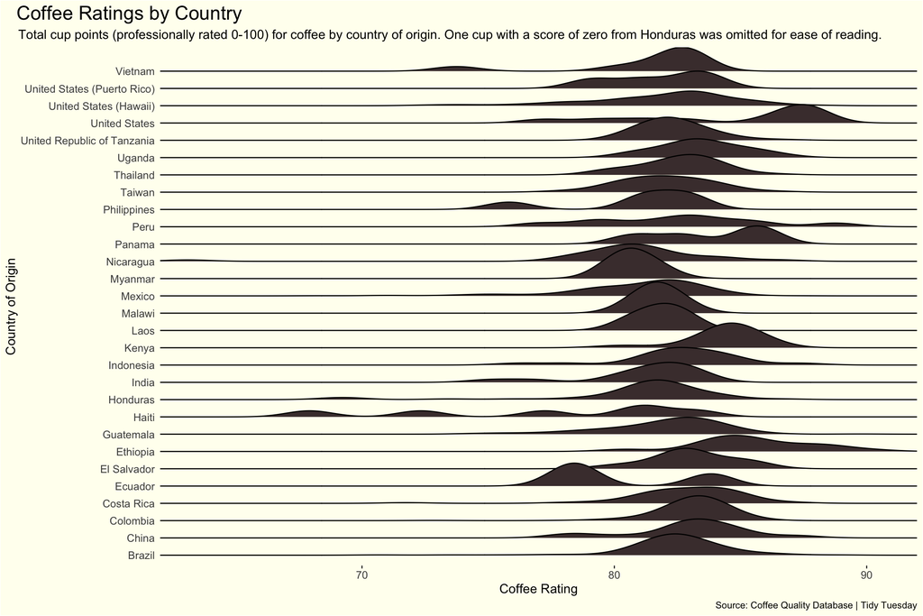

```r
coffee_dropped <- coffee %>%
  filter(total_cup_points > 0) %>%# get rid of that one weird zero-rated cup
  filter(!country_of_origin %in% c("Zambia", "Burundi", "Japan", "Papua New Guinea" ,"Rwanda", "Mauritius","Cote d?Ivoire")) %>%  # get rid of countries that don't have enough data o make a meaningful ridge
  drop_na(country_of_origin) # get rid of that one NA for country

coffee_dropped$country_of_origin[coffee_dropped$country_of_origin == "Tanzania, United Republic Of"] <- "United Republic of Tanzania"


pal <- pnw_palette("Moth")[c(1)]

ggplot(coffee_dropped,
       aes(x = total_cup_points, # use points for ridgeline on x axis
           y = country_of_origin)) + # put country on y axis
  geom_density_ridges(fill = pal) + # fill ridges with a color of my choosing
  theme(panel.background = element_blank(), # get rid of panel background
        panel.grid = element_blank(), # get rid of panel grid
        plot.background = element_rect(fill = "ivory"), # give plot background a fill color
        axis.ticks.y = element_blank(), # get rid of y axis ticks
        axis.text = element_text(size = 10), # adjust axis text size
        axis.title.x = element_text(size = 12), # adjust x axis title size
        axis.title.y = element_text(size = 12), # adjust y axis title size
        plot.title = element_text(size = 18, hjust = -0.27), # adjust title placement
        plot.subtitle = element_text(size = 12, hjust = 1.33)) + # adjust subtitle placement
  labs(title = "Coffee Ratings by Country", # add title
       subtitle = "Total cup points (professionally rated 0-100) for coffee by country of origin. One cup with a score of zero from Honduras was omitted for ease of reading.", # add subtitle
       caption = "Source: Coffee Quality Database | Tidy Tuesday", # add caption
       x = "Coffee Rating", # change x axis title
       y = "Country of Origin") + # change y axis title
  scale_x_continuous(limits = c(62, 92), expand = c(0, 0)) # mess with limits and remove weird empty space around axis
```